# Assignment8_MA

Akshita

2024-04-11

1. Model Development

```r
fish_data <- read.csv("C:/Users/HP/Desktop/USA/Spring'24/Multivariate/Datasets/Fish_dataset.csv")
str(fish_data)
```

```
## 'data.frame':    158 obs. of  7 variables:
##  $ Species: chr  "Bream" "Bream" "Bream" "Bream" ...
##  $ Weight : num  242 290 340 363 430 450 500 390 450 500 ...
##  $ Length1: num  23.2 24 23.9 26.3 26.5 26.8 26.8 27.6 27.6 28.5 ...
##  $ Length2: num  25.4 26.3 26.5 29 29 29.7 29.7 30 30 30.7 ...
##  $ Length3: num  30 31.2 31.1 33.5 34 34.7 34.5 35 35.1 36.2 ...
##  $ Height : num  11.5 12.5 12.4 12.7 12.4 ...
##  $ Width  : num  4.02 4.31 4.7 4.46 5.13 ...
```

```r
model_fit <- lm(Weight ~ Length1 + Height + Width, data = fish_data)
#show the results
summary(model_fit)
```

```
##
## Call:
## lm(formula = Weight ~ Length1 + Height + Width, data = fish_data)
##
## Residuals:
##     Min      1Q  Median      3Q     Max
## -249.24  -73.13  -27.96   75.11  443.17
##
## Coefficients:
##             Estimate Std. Error t value Pr(>|t|)
## (Intercept) -511.471     28.593 -17.888  < 2e-16 ***
## Length1       22.605      2.019  11.198  < 2e-16 ***
## Height        13.590      3.848   3.532 0.000545 ***
## Width         44.266     15.321   2.889 0.004420 **
## ---
## Signif. codes:  0 '***' 0.001 '**' 0.01 '*' 0.05 '.' 0.1 ' ' 1
##
## Residual standard error: 123.6 on 154 degrees of freedom
## Multiple R-squared:  0.8828, Adjusted R-squared:  0.8805
## F-statistic: 386.7 on 3 and 154 DF,  p-value: < 2.2e-16
```

```r
#Summary has three sections. Section1: How well does the model fit the data (before Coefficients). Section2: Is the hypothesis supported? (until sifnif codes). Section3: How well does data fit the model (again).
# Useful Helper Functions
coefficients(model_fit)
```

```
## (Intercept)     Length1      Height       Width
##  -511.47059    22.60470    13.58978    44.26608
```

Length1: For each unit increase in the length of the fish (Length1), the weight might increase by approximately 22.605 units.

Height: For each unit increase in the height of the fish (Height), the weight might increase by approximately 13.590 units.

Width: For each unit increase in the width of the fish (Width), the weight might increase by approximately 44.266 units.

All predictor variables have p-values less than 0.05, indicating that they are statistically significant in predicting the weight of the fish. Therefore, we can reject the null hypothesis.

The multiple R-squared value of 0.8828 indicates that approximately 88.28% of the variance in the weight of the fish is explained by the predictor variables (Length1, Height, and Width) included in the model.

This suggests that the model provides a good fit to the data and that the predictor variables collectively have a strong relationship with the weight of the fish.

The F-statistic of 386.7 with a very low p-value indicates that the model as a whole is statistically significant. This means that at least one of the predictor variables (Length1, Height, or Width) has a non-zero coefficient in the model.

2. Model Acceptance

```r
# Assess the acceptance of the model
# Check R-squared and adjusted R-squared
r_squared <- summary(model_fit)$r.squared
adj_r_squared <- summary(model_fit)$adj.r.squared
cat("R-squared:", r_squared, "\n")
```

```
## R-squared: 0.8828
```

```r
cat("Adjusted R-squared:", adj_r_squared, "\n")
```

```
## Adjusted R-squared: 0.8805169
```

```r
# Check the F-statistic and its p-value
f_statistic <- summary(model_fit)$fstatistic
f_statistic_value <- f_statistic[1]
f_statistic_p_value <- pf(f_statistic_value, f_statistic[2], f_statistic[3], lower.tail = FALSE)
cat("F-statistic:", f_statistic_value, "\n")
```

```
## F-statistic: 386.6645
```

```r
cat("p-value:", f_statistic_p_value, "\n")
```

```
## p-value: 1.899006e-71
```

The R-squared value is 0.8828, indicating that approximately 88.28% of the variance in the weight of the fish is explained by the predictor variables (Length1, Height, and Width) included in the model.

The F-statistic is 386.6645, indicating that the model as a whole is statistically significant. The associated p-value (1.899006e-71) is extremely small, indicating strong evidence against the null hypothesis that all coefficients in the model are zero.

Based on these observations, we can infer that the linear regression model is statistically significant and provides a good fit to the data. Therefore, we can accept the model for predicting the weight of the fish based on the provided predictor variables (Length1, Height, and Width).

3. Residual Analysis

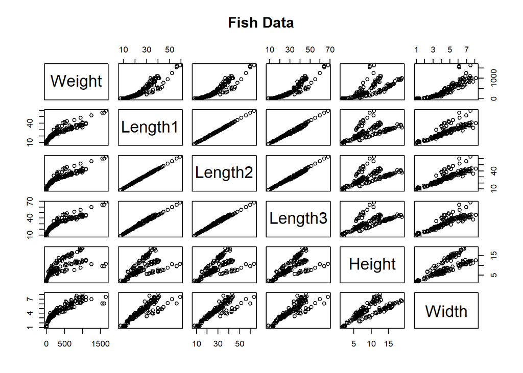

```r
# Select only numeric variables from fish_data
numeric_fish_data <- fish_data[, sapply(fish_data, is.numeric)]
# Plot pairs
pairs(numeric_fish_data, main = "Fish Data")
```

```r
confint(model_fit,level=0.95)
```

```
##                   2.5 %     97.5 %
## (Intercept) -567.955292 -454.98588
## Length1       18.616875   26.59252
## Height         5.988356   21.19120
## Width         13.998732   74.53344
```

```r
fitted(model_fit)
```

```
##           1           2           3           4           5           6
##  347.462289  391.234627  404.871188  453.258362  483.927163  497.305597
##           7           8           9          10          11          12
##  520.690080  492.209479  517.158596  545.632837  550.274046  545.711847
##          13          14          15          16          17          18
##  526.664831  568.994195  585.225554  609.911252  611.625706  608.789284
##          19          20          21          22          23          24
##  626.716778  639.509179  648.189348  653.392956  645.256773  688.951280
##          25          26          27          28          29          30
##  677.727187  697.639012  703.813405  711.188366  733.868291  795.697142
##          31          32          33          34          35          36
##  803.966487  803.973561  860.467653  885.872586  869.004449  -63.114984
##          37          38          39          40          41          42
##   58.415250   88.449198  116.790363  151.666682  154.411149  155.982360
##          43          44          45          46          47          48
##  194.739693  199.126151  216.617775  199.425834  220.674227  257.992864
##          49          50          51          52          53          54
##  240.549152  271.309077  291.208917  350.731617  381.392644  521.311910
##          55          56          57          58          59          60
##  323.912665  332.061255  393.736836  569.245906  701.127341  788.408941
##          61          62          63          64          65          66
##  -10.266125    3.599844   75.944245  127.332610  171.066382  179.872937
##          67          68          69          70          71          72
##  196.673268  208.170387  270.519345  342.559560  372.953343 -250.907098
##          73          74          75          76          77          78
##  -92.470377  -39.903335    6.500198   35.981751   72.730993   77.204990
##          79          80          81          82          83          84
##   88.939889   95.139115   91.703743  152.744404  144.846248  157.724339
##          85          86          87          88          89          90
##  167.993556  174.493586  173.307656  179.694851  176.501253  192.515917
##          91          92          93          94          95          96
##  191.927739  204.647770  198.035201  194.655137  224.697428  249.745637
##          97          98          99         100         101         102
##  241.785363  275.304639  259.002950  296.546266  334.497029  398.683663
##         103         104         105         106         107         108
##  351.982859  350.411880  363.788156  366.372046  404.867964  431.654361
##         109         110         111         112         113         114
##  580.671450  634.012899  724.391995  708.801899  699.653257  692.946028
##         115         116         117         118         119         120
##  696.143450  796.648264  730.674092  810.217634  799.322272  804.133769
##         121         122         123         124         125         126
##  823.486765  771.970002  848.101658  872.493619  893.319288  928.938266
##         127         128         129         130         131         132
##  923.538816  391.762815  466.724436  502.457598  538.571650  592.649388
##         133         134         135         136         137         138
##  565.264959  682.991044  682.850016  727.855098  749.238310  786.519724
##         139         140         141         142         143         144
##  843.563823  974.816235 1118.392296 1156.825161 1156.825161 1300.249552
##         145         146         147         148         149         150
## -231.243844 -207.275912 -208.839398 -185.451384 -184.753455 -183.565783
##         151         152         153         154         155         156
## -169.122297 -174.341268 -172.984558 -161.419279 -157.798805 -151.420474
##         157         158
##  -82.541017  -76.492989
```

```r
residuals(model_fit)
```

```
##            1            2            3            4            5            6
## -105.4622890 -101.2346268  -64.8711878  -90.2583616  -53.9271631  -47.3055971
##            7            8            9           10           11           12
##  -20.6900797 -102.2094786  -67.1585958  -45.6328365  -75.2740457  -45.7118467
##           13           14           15           16           17           18
##  -26.6648310 -228.9941950   14.7744457   -9.9112523   88.3742938   91.2107160
##           19           20           21           22           23           24
##  -16.7167783   10.4908206  -73.1893478   31.6070437  -25.2567726   -8.9512797
##           25           26           27           28           29           30
##   22.2728129   27.3609879   16.1865949    2.8116343  116.1317090  204.3028578
##           31           32           33           34           35           36
##  116.0335125  151.0264390   64.5323465   89.1274135   80.9955510  103.1149843
##           37           38           39           40           41           42
##   10.5847497  -10.4491983  -29.7903635  -31.6666822  -44.4111487  -35.9823598
##           43           44           45           46           47           48
##  -44.7396930  -54.1261508  -56.6177747  -59.4258337  -60.6742270  -88.9928641
##           49           50           51           52           53           54
##  -79.5491519  -71.3090772 -111.2089168  -60.7316174 -109.3926440 -131.3119102
##           55           56           57           58           59           60
##  -53.9126648  -62.0612555  -87.7368360  -29.2459058   98.8726589  211.5910595
##           61           62           63           64           65           66
##   65.2661248   56.4001563   14.0557546   -7.3326097  -21.0663818  -39.8729372
##           67           68           69           70           71           72
##  -26.6732677  -63.1703867  -70.5193452  -69.5595603  -72.9533431  256.8070981
##           73           74           75           76           77           78
##  124.4703768   79.9033346   44.9998023   34.0182495   27.2690074    0.7950096
##           79           80           81           82           83           84
##   -8.9398887  -10.1391148   -6.7037431  -42.7444041  -29.8462481  -32.7243386
##           85           86           87           88           89           90
##  -37.9935565  -54.4935862  -53.3076559  -49.6948511  -41.5012535  -82.5159167
##           91           92           93           94           95           96
##  -61.9277389  -54.6477702  -53.0352012  -44.6551369  -54.6974276  -24.7456372
##           97           98           99          100          101          102
##  -96.7853625  -87.3046387  -79.0029498  -99.5462664 -116.4970294  -98.6836631
##          103          104          105          106          107          108
##  -91.9828587  -85.4118805 -113.7881557 -116.3720461 -104.8679637 -111.6543614
##          109          110          111          112          113          114
##  -66.6714502  -78.0128993  115.6080055  -23.8018995    0.3467425    7.0539725
##          115          116          117          118          119          120
##   -6.1434496  103.3517360  -80.6740918    9.7823659   50.6777282   95.8662306
##          121          122          123          124          125          126
##  191.5132352   48.0299984  251.8983417  127.5063809  206.6807123   71.0617337
##          127          128          129          130          131          132
##   76.4611835 -191.7628148 -166.7244359 -202.4575981 -238.5716501 -162.6493883
##          133          134          135          136          137          138
## -220.2649588 -226.9910443 -172.8500162 -187.8550980 -249.2383102 -219.5197236
##          139          140          141          142          143          144
##  -73.5638234  -24.8162355  131.6077040  443.1748388  393.1748388  349.7504475
##          145          146          147          148          149          150
##  237.9438441  214.7759119  215.8393984  195.1513842  194.5534553  192.2657834
##          151          152          153          154          155          156
##  179.1222967  184.2412680  182.7845576  173.6192786  171.1988049  163.6204741
##          157          158
##  102.2410166   96.3929892
```

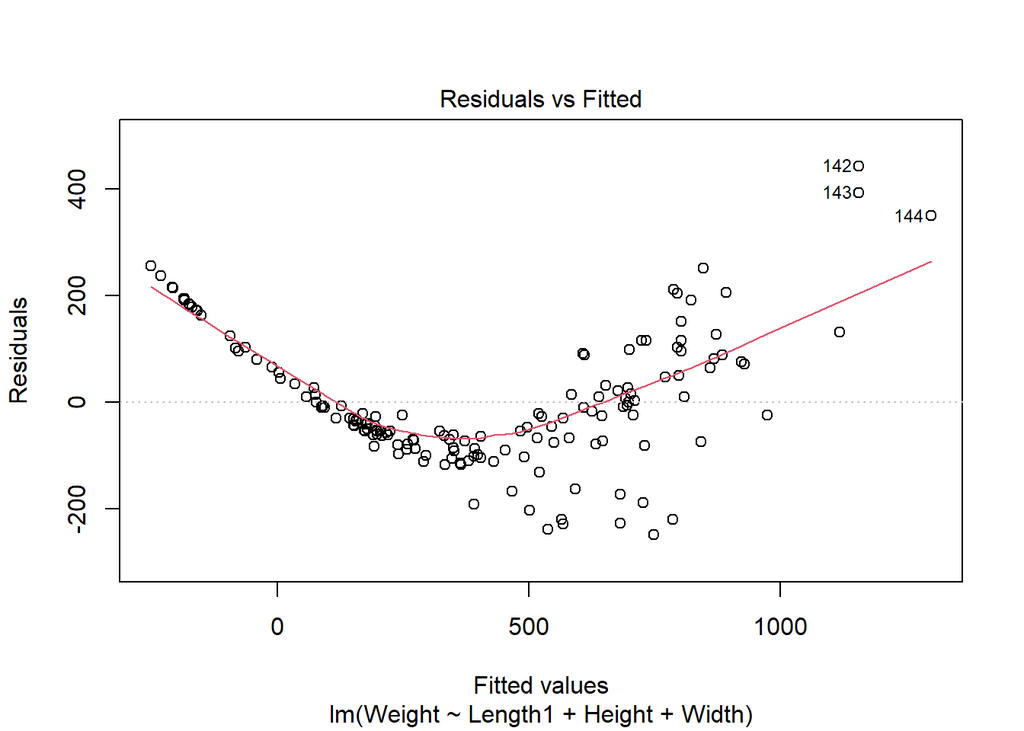

```r
# Plot residuals vs. fitted values
plot(model_fit, which = 1)
```

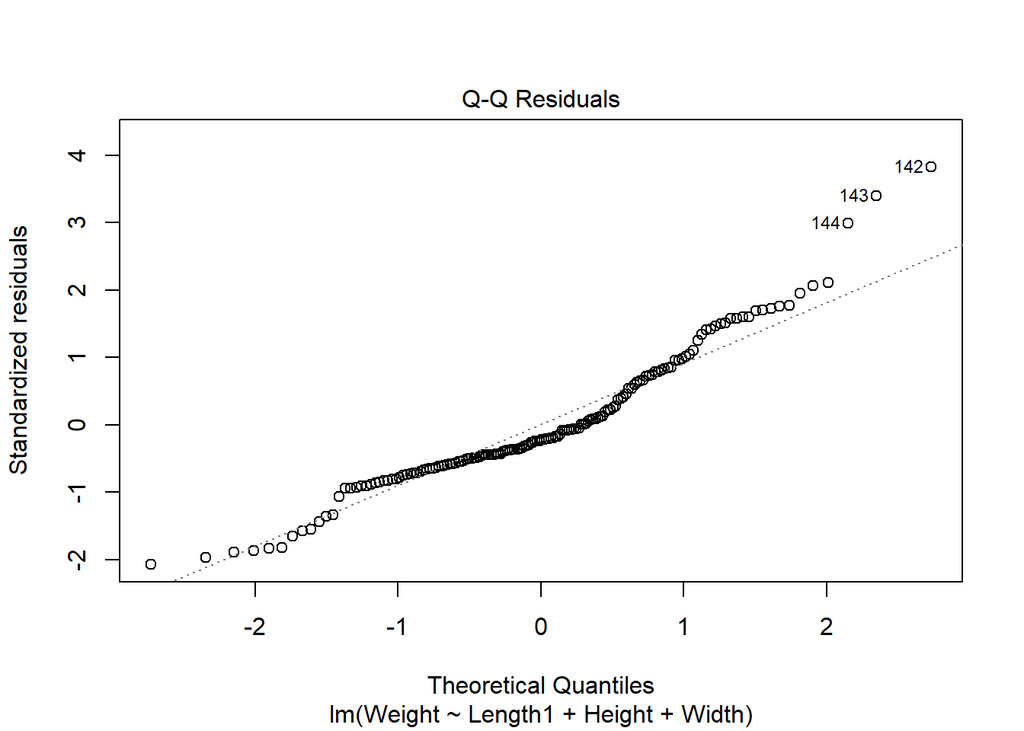

```r
# Plot normal Q-Q plot of residuals
plot(model_fit, which = 2)
```

The points are mostly normally distributed but we can see some deviation along the line which means not all points follow the normal distribution. We can see some point far away from the line as well which means our data might contain outliers.

4. Prediction

```r
# Make predictions
predictions <- predict(model_fit, newdata = fish_data)

# Print predictions
print(predictions)
```

```
##           1           2           3           4           5           6
##  347.462289  391.234627  404.871188  453.258362  483.927163  497.305597
##           7           8           9          10          11          12
##  520.690080  492.209479  517.158596  545.632837  550.274046  545.711847
##          13          14          15          16          17          18
##  526.664831  568.994195  585.225554  609.911252  611.625706  608.789284
##          19          20          21          22          23          24
##  626.716778  639.509179  648.189348  653.392956  645.256773  688.951280
##          25          26          27          28          29          30
##  677.727187  697.639012  703.813405  711.188366  733.868291  795.697142
##          31          32          33          34          35          36
##  803.966487  803.973561  860.467653  885.872586  869.004449  -63.114984
##          37          38          39          40          41          42
##   58.415250   88.449198  116.790363  151.666682  154.411149  155.982360
##          43          44          45          46          47          48
##  194.739693  199.126151  216.617775  199.425834  220.674227  257.992864
##          49          50          51          52          53          54
##  240.549152  271.309077  291.208917  350.731617  381.392644  521.311910
##          55          56          57          58          59          60
##  323.912665  332.061255  393.736836  569.245906  701.127341  788.408941
##          61          62          63          64          65          66
##  -10.266125    3.599844   75.944245  127.332610  171.066382  179.872937
##          67          68          69          70          71          72
##  196.673268  208.170387  270.519345  342.559560  372.953343 -250.907098
##          73          74          75          76          77          78
##  -92.470377  -39.903335    6.500198   35.981751   72.730993   77.204990
##          79          80          81          82          83          84
##   88.939889   95.139115   91.703743  152.744404  144.846248  157.724339
##          85          86          87          88          89          90
##  167.993556  174.493586  173.307656  179.694851  176.501253  192.515917
##          91          92          93          94          95          96
##  191.927739  204.647770  198.035201  194.655137  224.697428  249.745637
##          97          98          99         100         101         102
##  241.785363  275.304639  259.002950  296.546266  334.497029  398.683663
##         103         104         105         106         107         108
##  351.982859  350.411880  363.788156  366.372046  404.867964  431.654361
##         109         110         111         112         113         114
##  580.671450  634.012899  724.391995  708.801899  699.653257  692.946028
##         115         116         117         118         119         120
##  696.143450  796.648264  730.674092  810.217634  799.322272  804.133769
##         121         122         123         124         125         126
##  823.486765  771.970002  848.101658  872.493619  893.319288  928.938266
##         127         128         129         130         131         132
##  923.538816  391.762815  466.724436  502.457598  538.571650  592.649388
##         133         134         135         136         137         138
##  565.264959  682.991044  682.850016  727.855098  749.238310  786.519724
##         139         140         141         142         143         144
##  843.563823  974.816235 1118.392296 1156.825161 1156.825161 1300.249552
##         145         146         147         148         149         150
## -231.243844 -207.275912 -208.839398 -185.451384 -184.753455 -183.565783
##         151         152         153         154         155         156
## -169.122297 -174.341268 -172.984558 -161.419279 -157.798805 -151.420474
##         157         158
##  -82.541017  -76.492989
```

Each predicted weight represents the estimated weight of a fish based on its corresponding values of the predictor variables (Length1, Height, and Width) as per the fitted regression model.

The model estimates a wide range of fish weights, from negative values to over 1300 units. However, negative weights are not meaningful in this context and suggest potential issues with the model, such as overfitting or outliers in the data.

5. Model Accuracy

```r
# Calculate Mean Squared Error (MSE)
mse <- mean(model_fit$residuals^2)

# Calculate Root Mean Squared Error (RMSE)
rmse <- sqrt(mse)

# Calculate Mean Absolute Error (MAE)
mae <- mean(abs(model_fit$residuals))

# Print the accuracy metrics
cat("Mean Squared Error (MSE):", mse, "\n")
```

```
## Mean Squared Error (MSE): 14900.56
```

```r
cat("Root Mean Squared Error (RMSE):", rmse, "\n")
```

```
## Root Mean Squared Error (RMSE): 122.0679
```

```r
cat("Mean Absolute Error (MAE):", mae, "\n")
```

```
## Mean Absolute Error (MAE): 94.08461
```

The MSE is 14900.56.This indicates that, on average, the squared difference between the observed and predicted values of the response variable (weight of the fish) is 14900.56 units squared.

The model’s performance appears moderate, with an RMSE of approximately 122.07 and an MAE of approximately 94.08.

These values indicate that, on average, the model’s predictions are off by around 122.07 units of weight when considering the RMSE and around 94.08 units of weight when considering the MAE.

```r
#Anova Table
anova(model_fit)
```

```
## Analysis of Variance Table
##
## Response: Weight
##            Df   Sum Sq  Mean Sq   F value    Pr(>F)
## Length1     1 16844460 16844460 1101.8389 < 2.2e-16 ***
## Height      1   761434   761434   49.8073 5.425e-11 ***
## Width       1   127609   127609    8.3472   0.00442 **
## Residuals 154  2354289    15288
## ---
## Signif. codes:  0 '***' 0.001 '**' 0.01 '*' 0.05 '.' 0.1 ' ' 1
```

```r
vcov(model_fit)
```

```
##             (Intercept)    Length1    Height     Width
## (Intercept)   817.54738 -14.640950  -6.73333 -62.23101
## Length1       -14.64095   4.074955   1.59158 -24.14096
## Height         -6.73333   1.591580  14.80610 -38.01190
## Width         -62.23101 -24.140957 -38.01190 234.74700
```

```r
cov2cor(vcov(model_fit))
```

```
##             (Intercept)    Length1      Height      Width
## (Intercept)  1.00000000 -0.2536597 -0.06120023 -0.1420530
## Length1     -0.25365966  1.0000000  0.20490223 -0.7805362
## Height      -0.06120023  0.2049022  1.00000000 -0.6447617
## Width       -0.14205298 -0.7805362 -0.64476170  1.0000000
```

```r
temp <- influence.measures(model_fit)
temp
```

[output not shown]

[output cut: 266 more lines]

[output not shown]

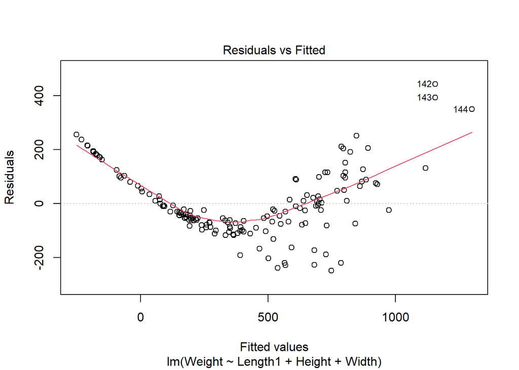

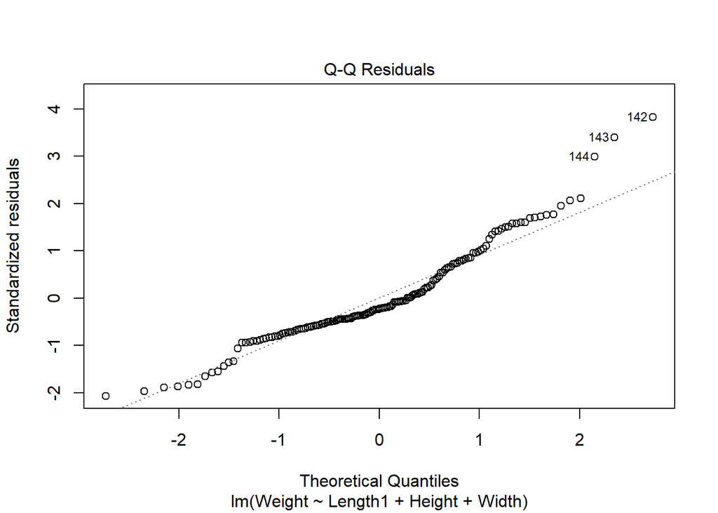

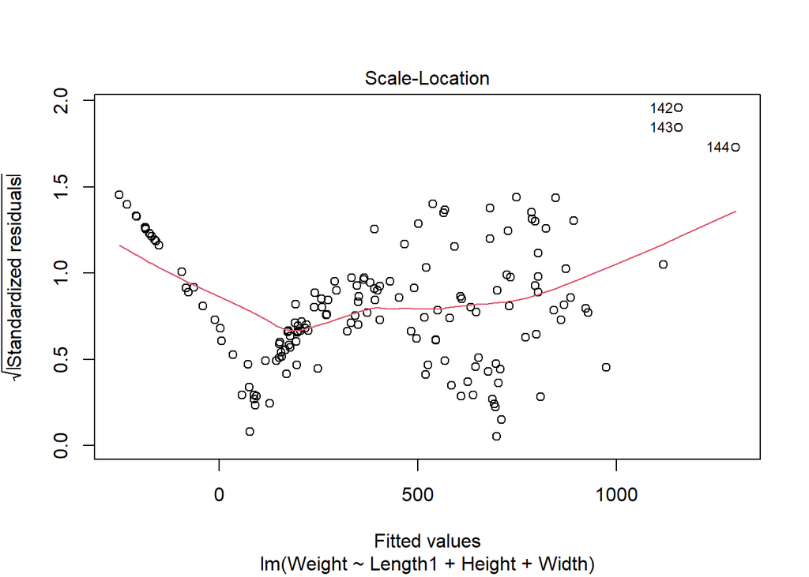

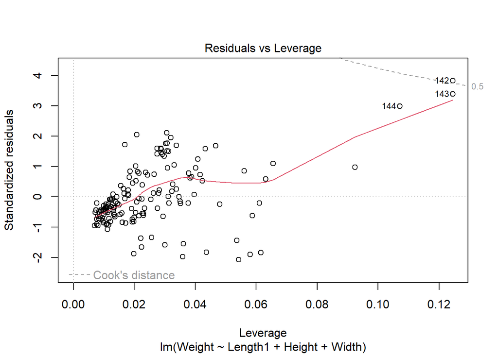

```r
plot(model_fit)
```

```r
anova_result <- anova(model_fit)
print(anova_result)
```

```
## Analysis of Variance Table
##
## Response: Weight
##            Df   Sum Sq  Mean Sq   F value    Pr(>F)
## Length1     1 16844460 16844460 1101.8389 < 2.2e-16 ***
## Height      1   761434   761434   49.8073 5.425e-11 ***
## Width       1   127609   127609    8.3472   0.00442 **
## Residuals 154  2354289    15288
## ---
## Signif. codes:  0 '***' 0.001 '**' 0.01 '*' 0.05 '.' 0.1 ' ' 1
```